# Assignment 7: Visualization - Some aspects of ggplot2

*How to do it?*:

- Open the Rmarkdown file of this assignment (link) in Rstudio.
- Right under each **question**, insert a code chunk (you can use the hotkey `Ctrl + Alt + I` to add a code chunk) and code the solution for the question.
- `Knit` the rmarkdown file (hotkey: `Ctrl + Alt + K`) to export an html.
- Publish the html file to your Githiub Page.

*Submission*: Submit the link on Github of the assignment to Canvas

### I. Questions on Your Selected Data

Use the data of your own. Produce the following types of plots and comment on each plot. Plots should be meaningful. If you use the data we used in class, make sure the plots are not the same as the ones in the slides. All plots should have title, caption, appropriate labels on x and y-axis.

1. Make a plot using `face_wrap` by one categorical variable (`face_wrap(~variable1)`)

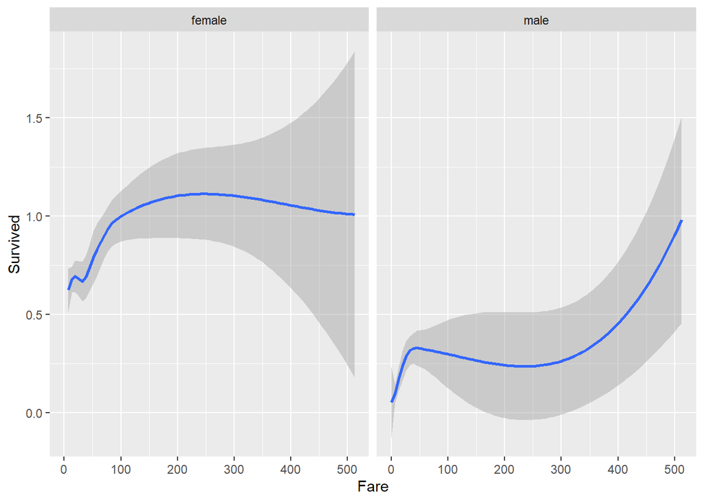

```r
library(tidyverse)
df = read_csv("titanic.csv")

df %>% ggplot(mapping=aes(x=Fare, y=Survived))+
geom_smooth()+facet_wrap(~Sex)
```

2. Make a plot using `face_wrap` by two categorical variables (`face_wrap(variable1~variable2)`)

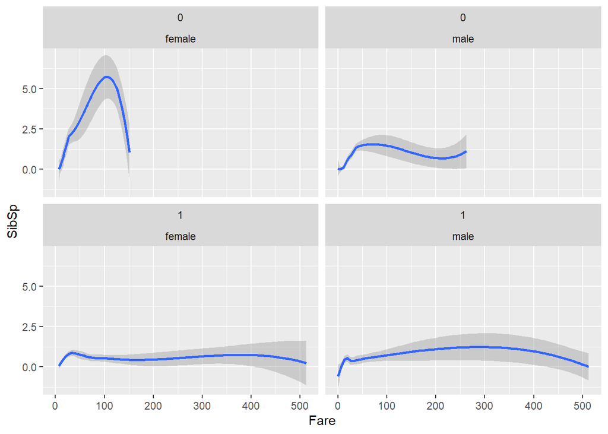

```r
df %>% ggplot(mapping=aes(x=Fare, y=SibSp))+
geom_smooth()+facet_wrap(Survived~Sex)
```

3. Make a plot using `position ='jitter'`.

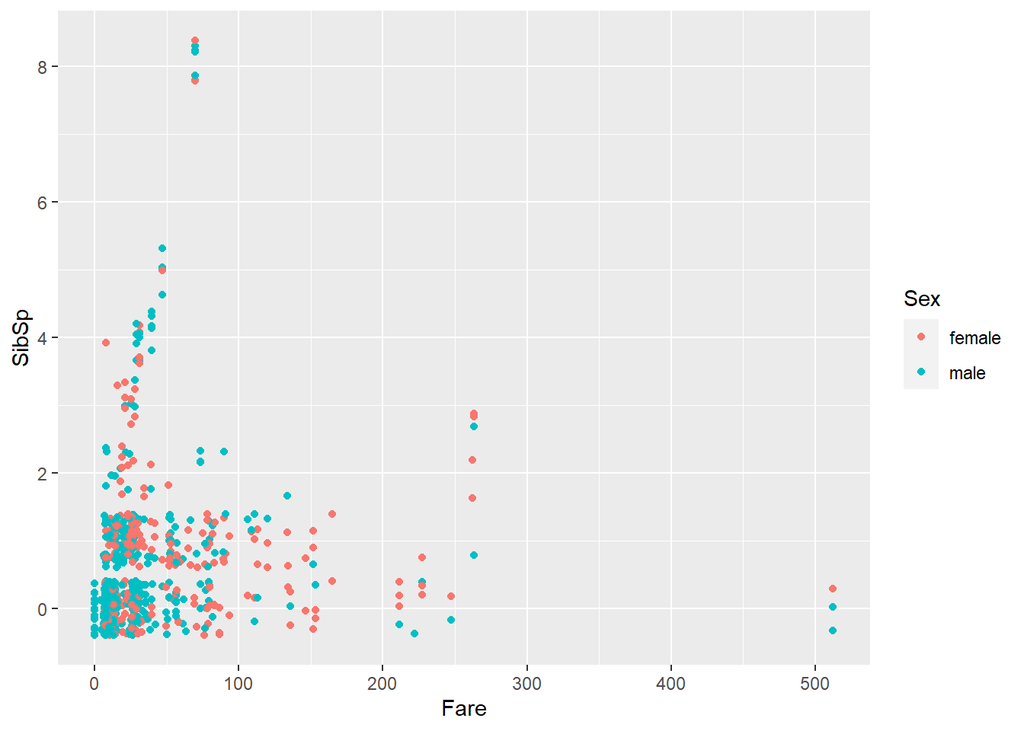

```r
df %>% ggplot()+  geom_point(mapping=aes(x=Fare, y=SibSp, color=Sex), position='jitter')
```

4. Make a plot using `position ='dodge'`.

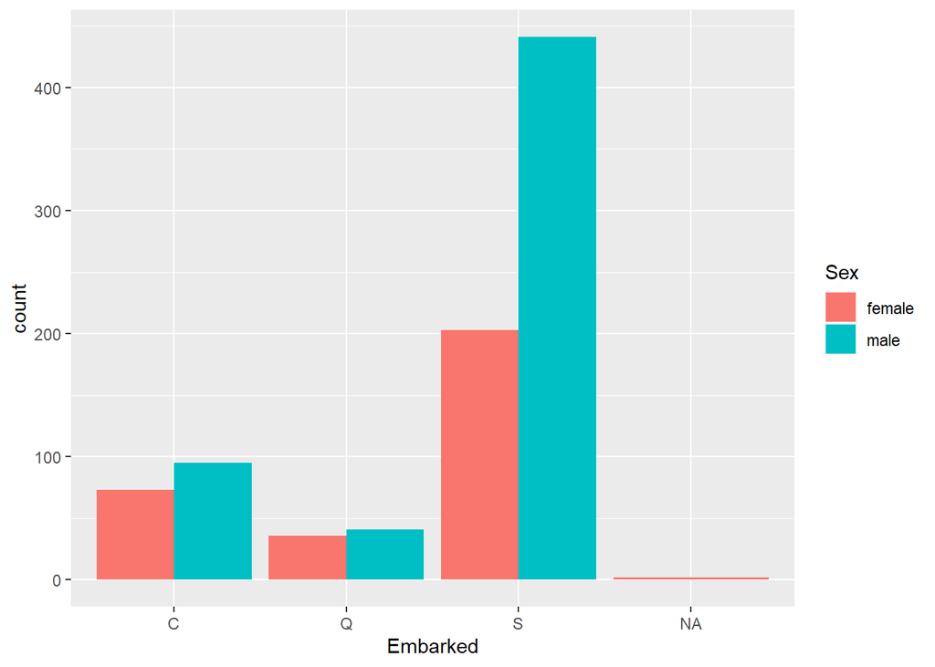

```r
df %>% ggplot()+ geom_bar(mapping=aes(x=Embarked, fill=Sex), position = 'dodge')
```

5. Make a plot using `position ='fill'`.

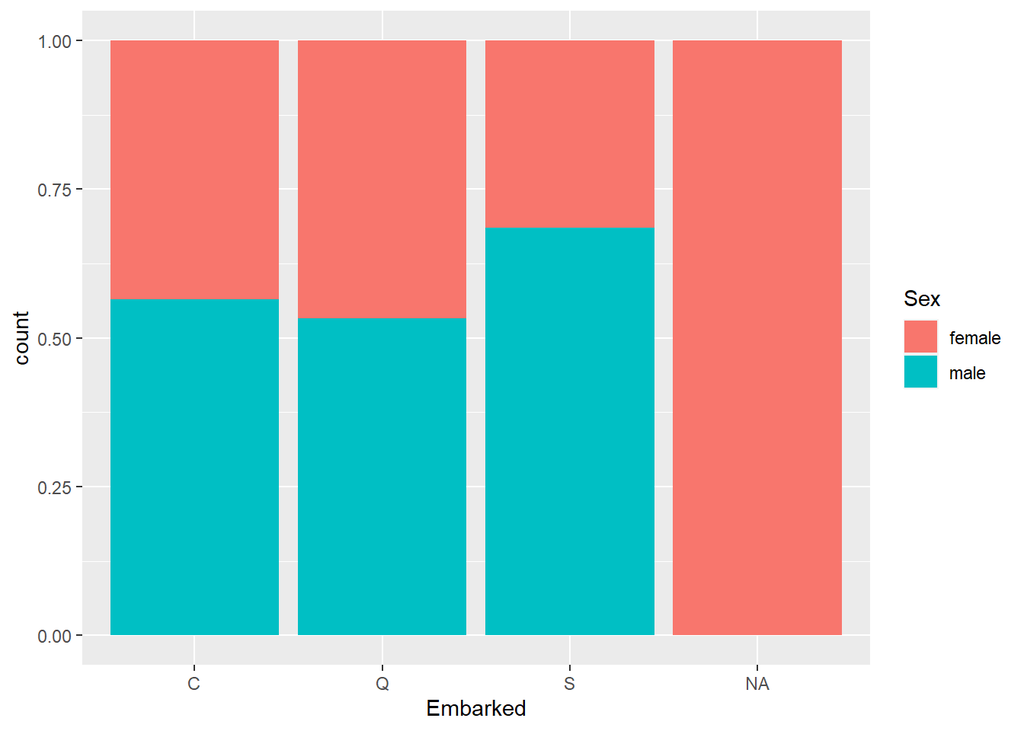

```r
df %>% ggplot()+ geom_bar(mapping=aes(x=Embarked, fill=Sex), position = 'fill')
```

6. Make a plot using `geom_col`.

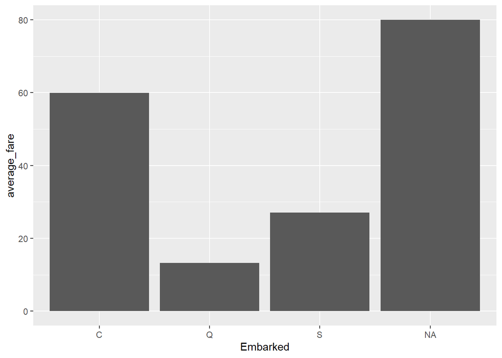

```r
df %>% group_by(Embarked) %>% summarise(average_fare=mean(Fare)) %>% ggplot()+ geom_col(mapping=aes(x=Embarked, y=average_fare))
```

7. Change the theme of one of your plots.

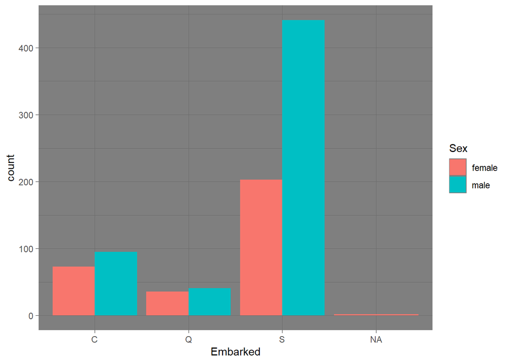

```r
df %>% ggplot()+ geom_bar(mapping=aes(x=Embarked, fill=Sex), position = 'dodge')+theme_dark()
```

```r
plot1 = df %>% ggplot()+ geom_bar(mapping=aes(x=Embarked, fill=Sex), position = 'dodge')+theme_dark()

ggsave(filename = 'plot1.png', plot = plot1)
```

### II. Questions on Covid Vaccination Data

In this section of questions, we will use the covid vaccination data for the US. The data and data dictionary can be found at the below link:

- [Data](https://raw.githubusercontent.com/govex/COVID-19/master/data_tables/vaccine_data/us_data/time_series/vaccine_data_us_timeline.csv)
- [Data Dictionary](https://github.com/govex/COVID-19/blob/master/data_tables/vaccine_data/us_data/data_dictionary.csv)

```r
library(tidyverse)
df <- read_csv('https://raw.githubusercontent.com/govex/COVID-19/master/data_tables/vaccine_data/us_data/time_series/vaccine_data_us_timeline.csv')
```

1. Put titles, captions, appropriate labels on x and y-axis for the last two questions in Assignments 6.

[figure not shown]

```r
library(lubridate)
df$month <- factor(month(df$Date, label = TRUE))

df3 <- df %>% filter(Province_State %in% c('Massachusetts','Connecticut', 'Rhode Island', 'Maine', 'Vermont', 'New Hampshire'), Vaccine_Type != "All") %>% group_by(month, Province_State) %>% summarise(vac_admin=mean(Doses_admin, na.rm=TRUE))

df3 %>%  ggplot()+geom_col(mapping = aes(x = month, y = vac_admin, fill = Province_State)) +
  labs(x='Month',
       y = 'Total Vaccines Admin',
       color='State',
       title = 'Vaccine Popularity by Month in NE',
       caption = 'October has the most administered vaccines and November has the least')
```

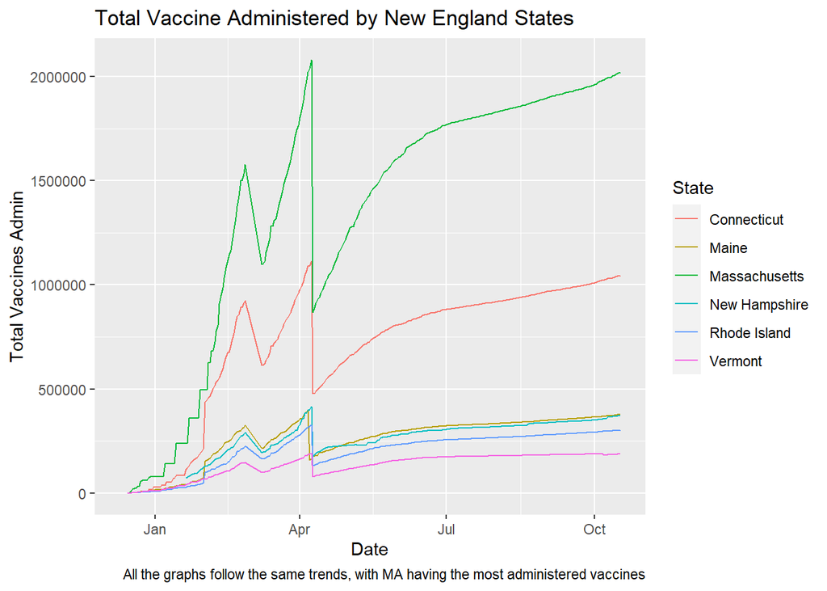

```r
df4 <- df %>% filter(Province_State %in% c('Massachusetts','Connecticut', 'Rhode Island', 'Maine', 'Vermont', 'New Hampshire'), Vaccine_Type != "All") %>% group_by(Date, Province_State) %>% summarise(vac_admin=mean(Doses_admin, na.rm=TRUE))

df4 %>%  ggplot()+geom_line(mapping = aes(x = Date, y = vac_admin, color = Province_State)) +
  labs(x='Date',
       y = 'Total Vaccines Admin',
       color='State',
       title = 'Total Vaccine Administered by New England States',
       caption = 'All the graphs follow the same trends, with MA having the most administered vaccines')
```

2. Since the data seems lack of categorical variables, we will create a few categorical variables for easier visualization. From the `Date` variable create three categorical variables to record weekdays, months and quarters. You could also create a categorical variable to record the state regions (South, North East, Midwest, West) or other new categorical variables.

```r
library(lubridate)
df$year <- year(df$Date)
df$quarters <- as.factor(quarter(df$Date))
df$day <- wday(df$Date)
```

3. With the updated data after question 2. Create at least 7 new meaningful graphs. Your graphs should have titles, captions, appropriate labels on x and y-axis. You should also make use of the follows.
- geom_point

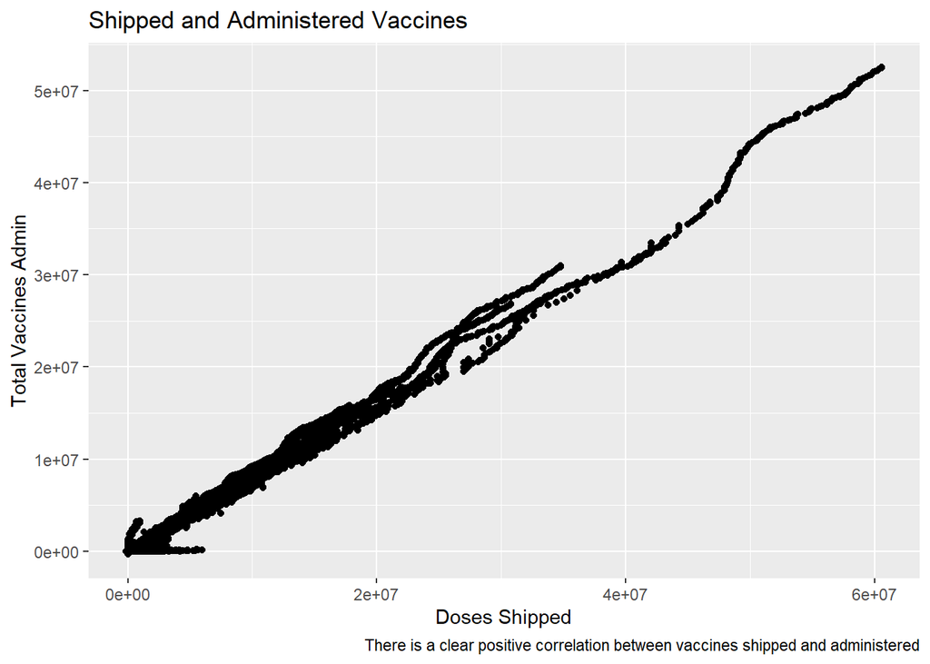

```r
 df %>%  ggplot()+geom_point(mapping = aes(x = Doses_shipped, y = Doses_admin)) +
  labs(x='Doses Shipped',
       y = 'Total Vaccines Admin',
       title = 'Shipped and Administered Vaccines',
       caption = 'There is a clear positive correlation between vaccines shipped and administered')
```

- geom_line

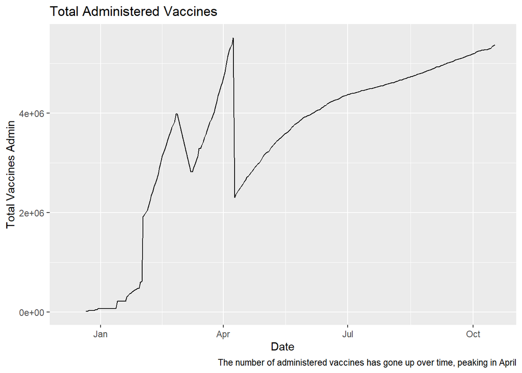

```r
df5 <- df %>% filter( Vaccine_Type != "All", Province_State %in%  c("New York")) %>% group_by(Date) %>% summarise(vac_admin=mean(Doses_admin, na.rm=TRUE))

  df5 %>%  ggplot()+geom_line(mapping = aes(x = Date, y = vac_admin)) +
  labs(x='Date',
       y = 'Total Vaccines Admin',
       title = 'Total Administered Vaccines',
       caption = 'The number of administered vaccines has gone up over time, peaking in April')
```

- geom_smooth

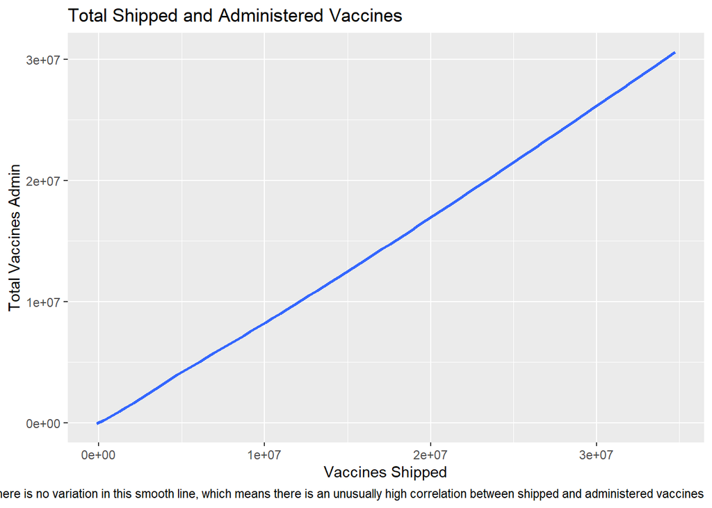

```r
df %>% filter(Vaccine_Type != "All") %>% ggplot(mapping = aes(x = Doses_shipped, y = Doses_admin))+geom_smooth() +
  labs(x='Vaccines Shipped',
       y = 'Total Vaccines Admin',
       title = 'Total Shipped and Administered Vaccines',
       caption = 'There is no variation in this smooth line, which means there is an unusually high correlation between shipped and administered vaccines')
```

_ geom_bar